# Analyse des données des joueurs (expérimentations finales)

### Courbes de difficulte

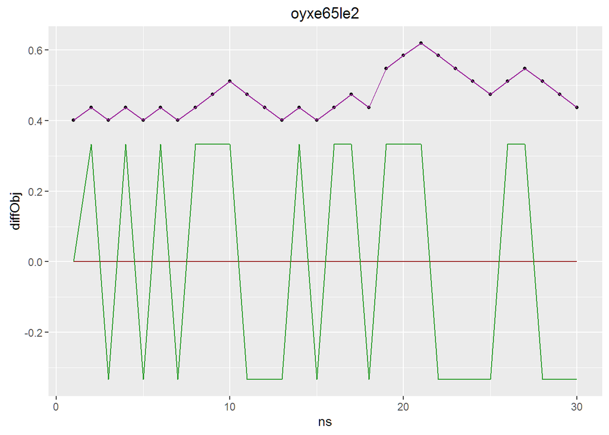

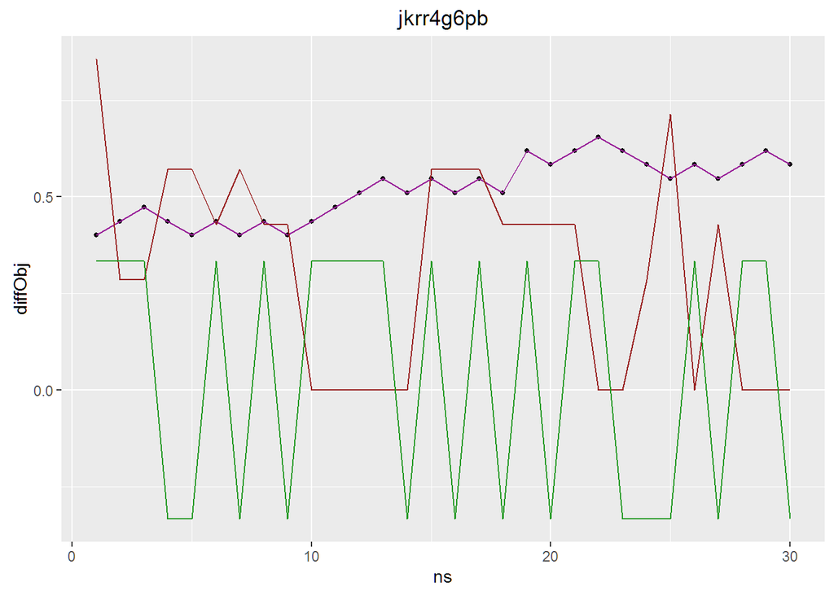

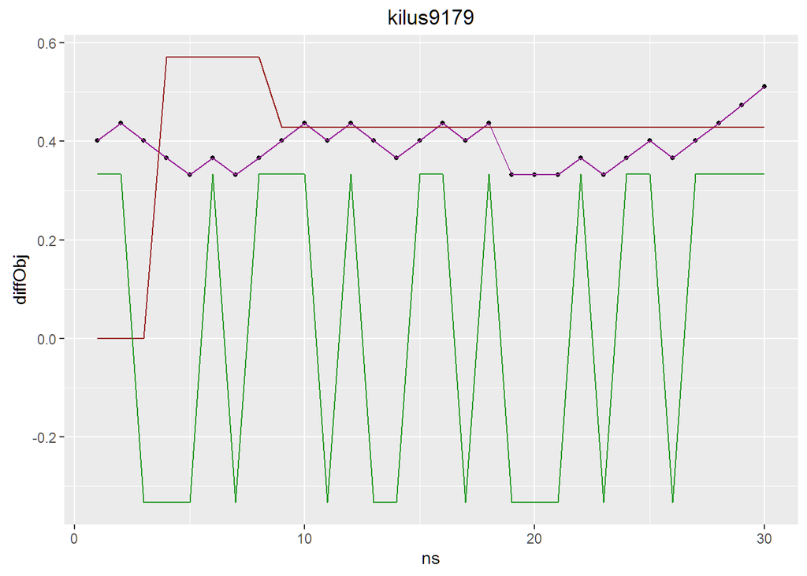

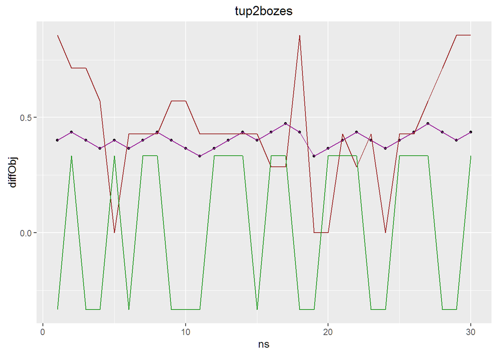

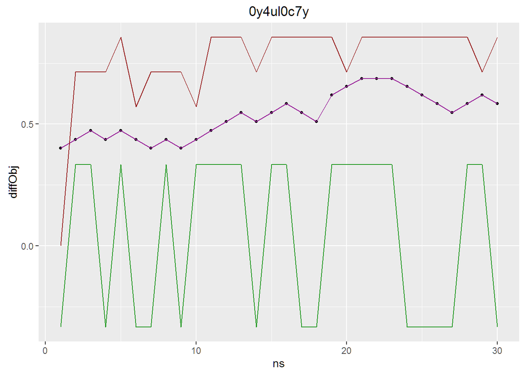

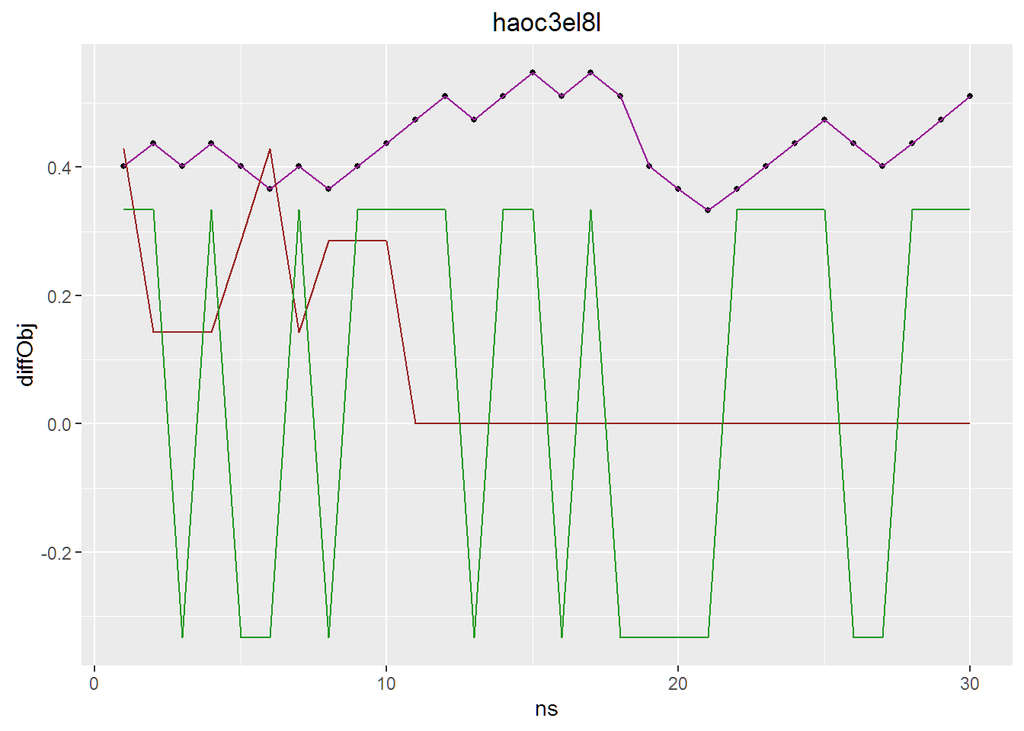

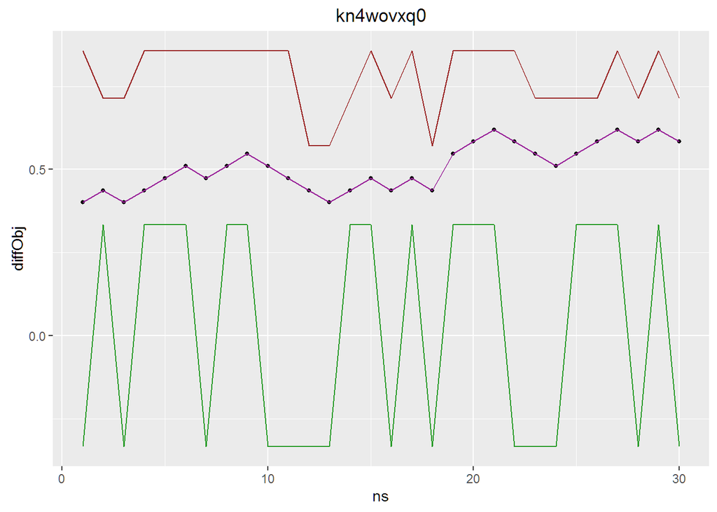

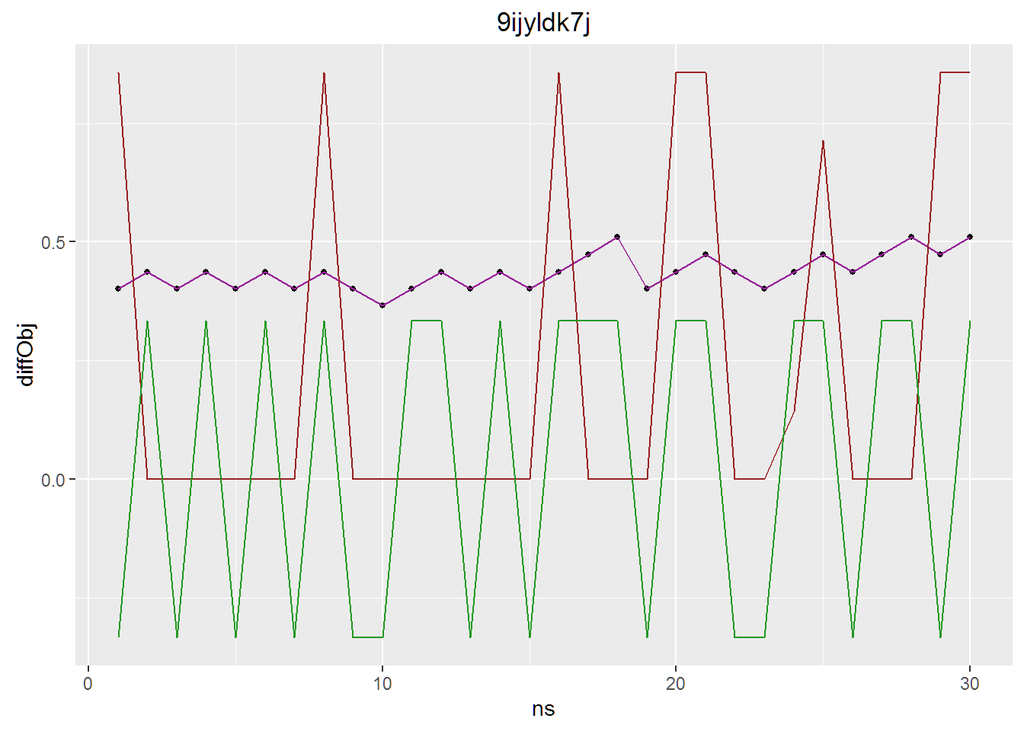

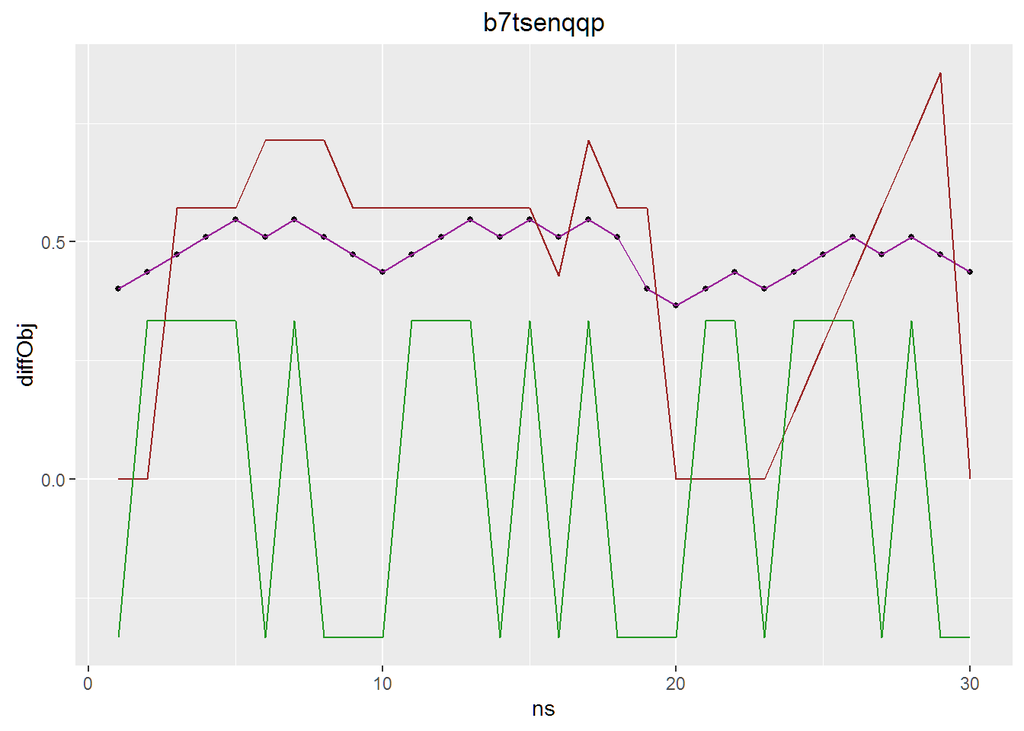

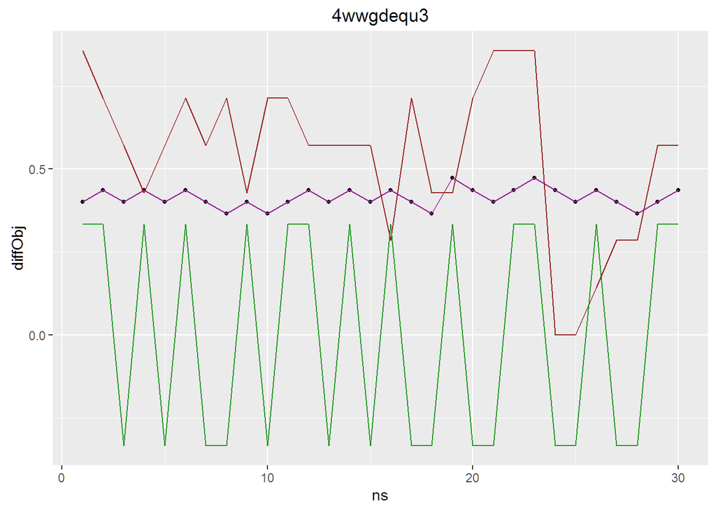

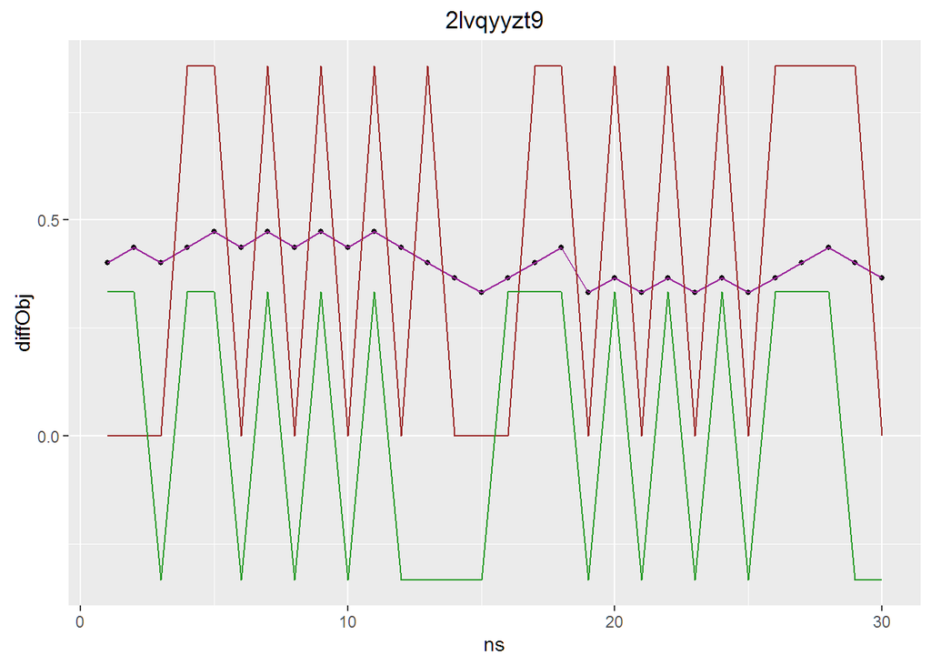

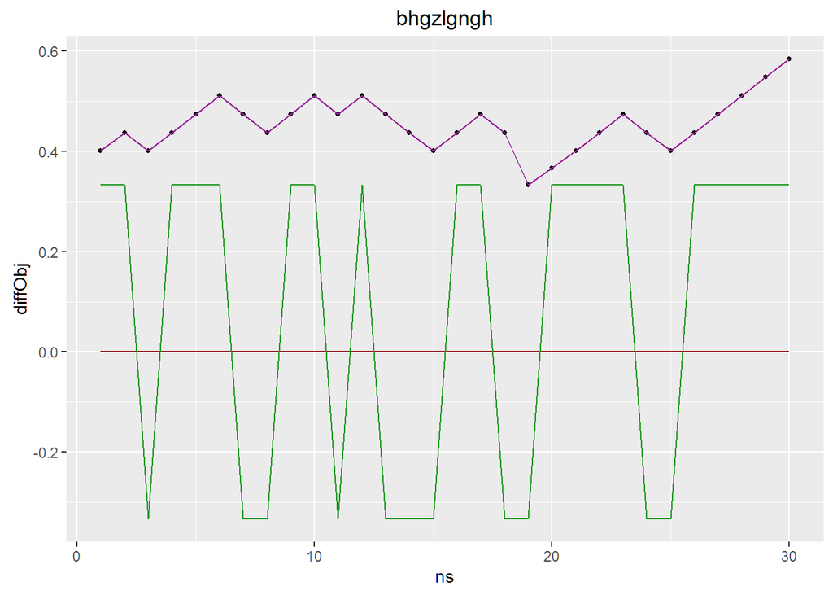

[13 more figures not shown]

## Difficulté sensorielle

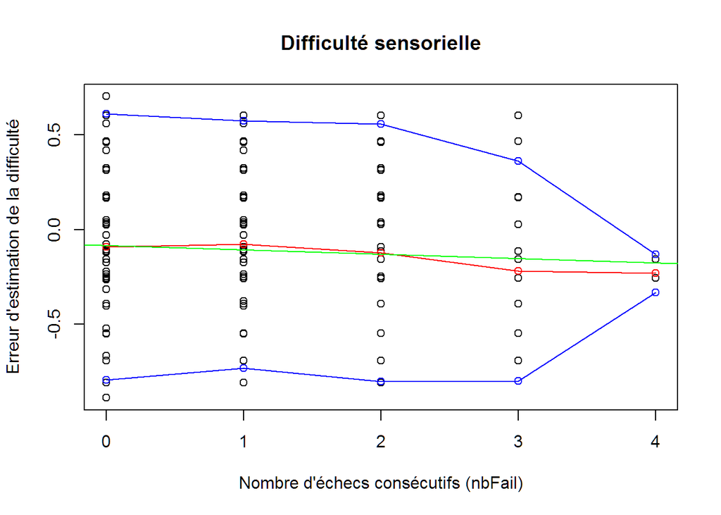

```
## [1] "Anova"
## [1] "Regression linéaire"
```

```
## [1] "pvalue anova"
```

```
## [1] "0.11 :("
```

```
## [1] "plotLinModels == FALSE"
```

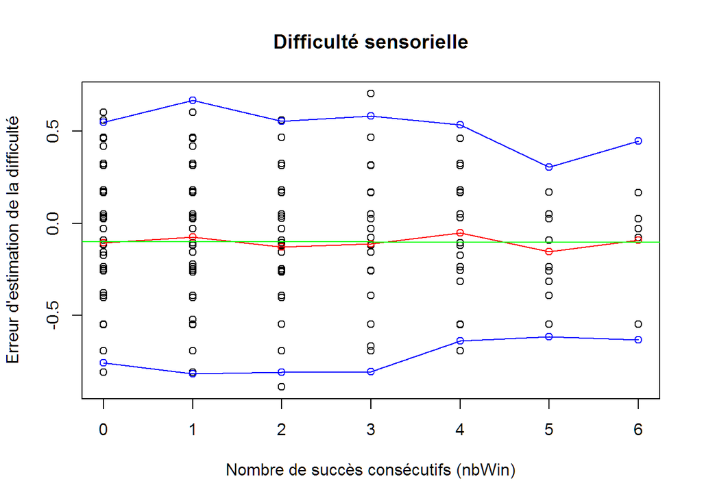

```
## [1] "Anova"
## [1] "Regression linéaire"
```

```
## [1] "pvalue anova"
```

```
## [1] "0.94 :("
```

```
## [1] "plotLinModels == FALSE"
```

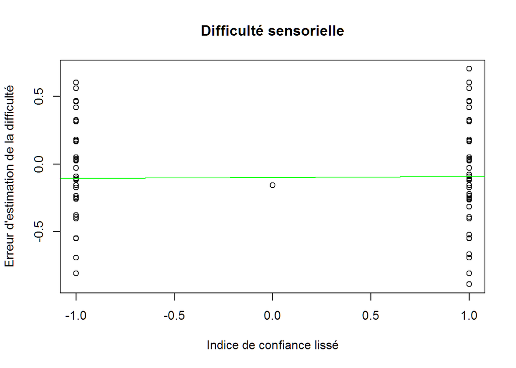

```
## [1] "Anova res lisse"
## [1] "Regression linéaire"
```

```
## [1] "pvalue anova"
```

```
## [1] "0.64 :("
```

```
## [1] "plotLinModels == FALSE"
```

### Courbes de difficulte

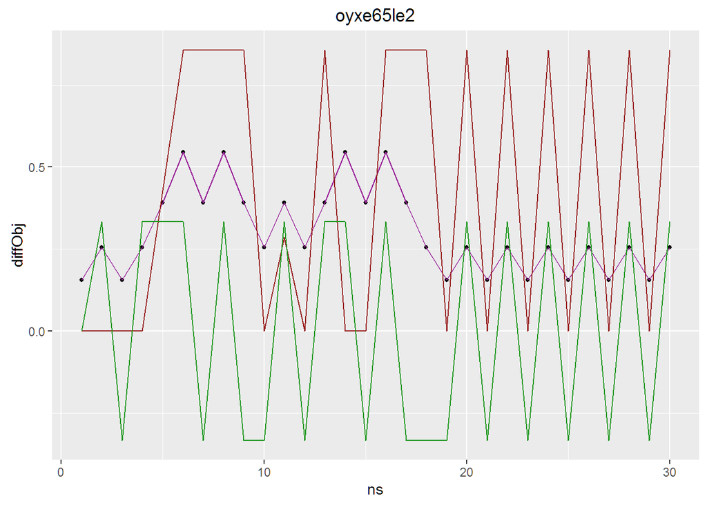

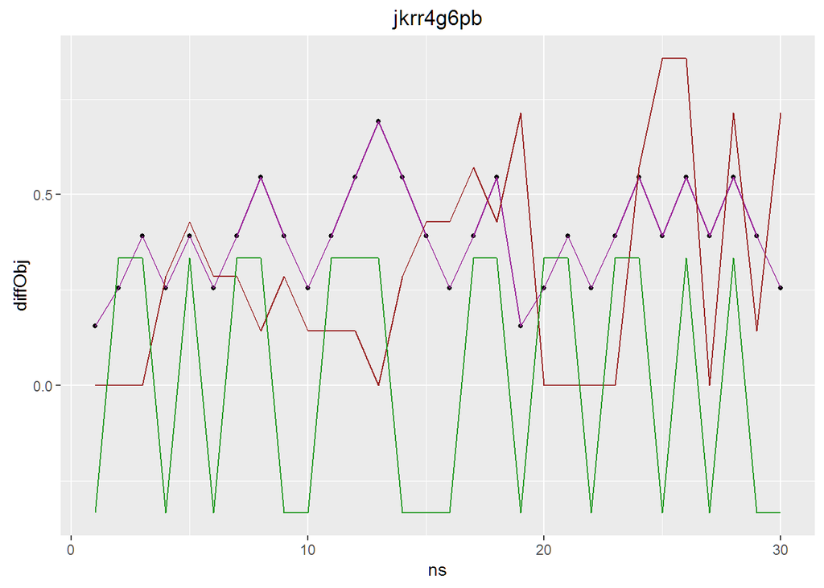

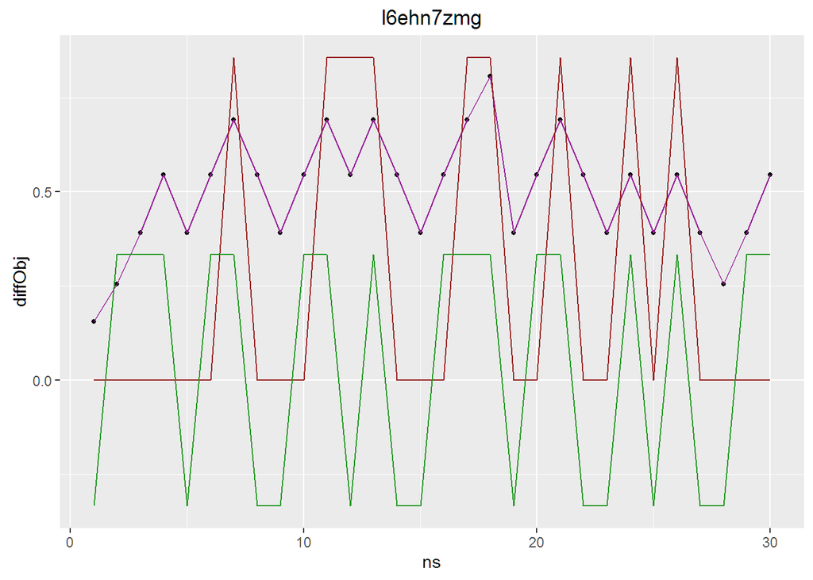

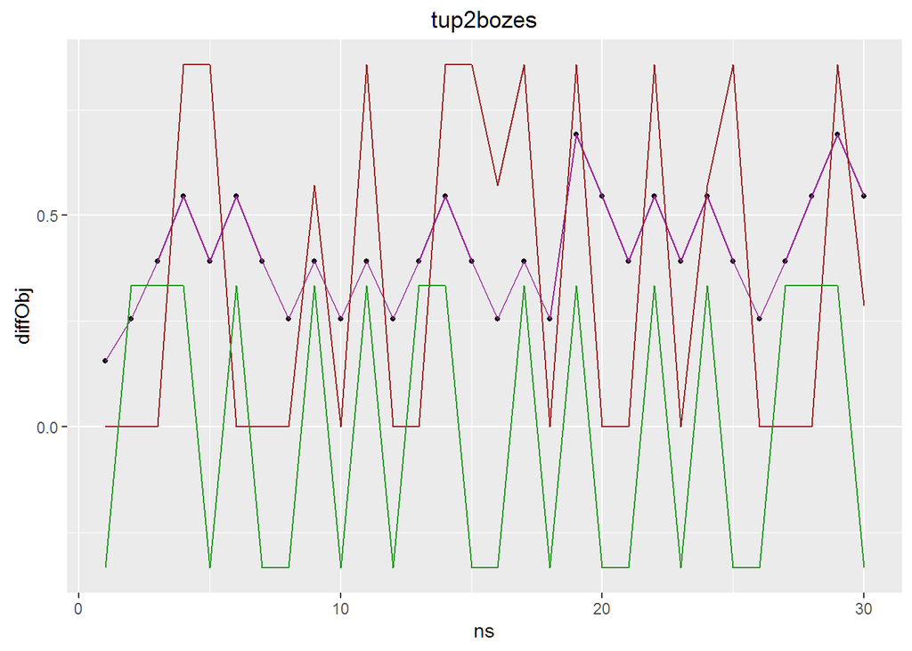

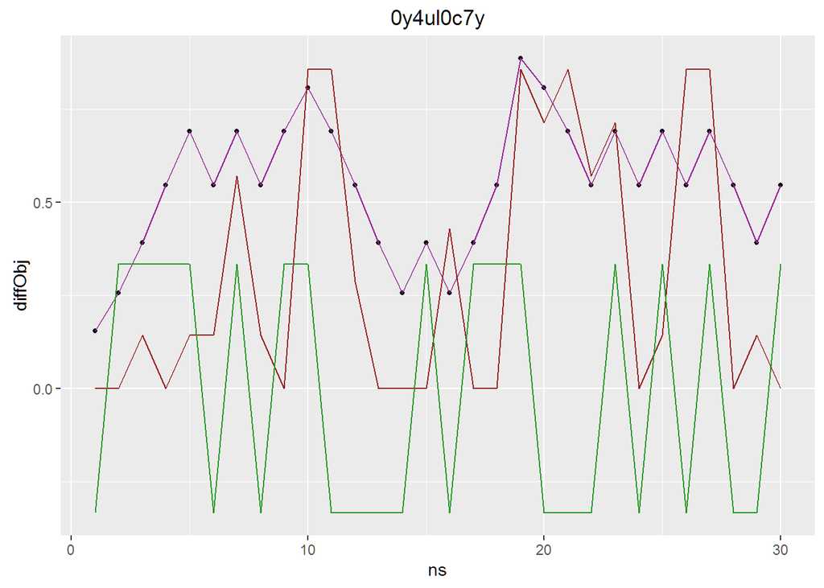

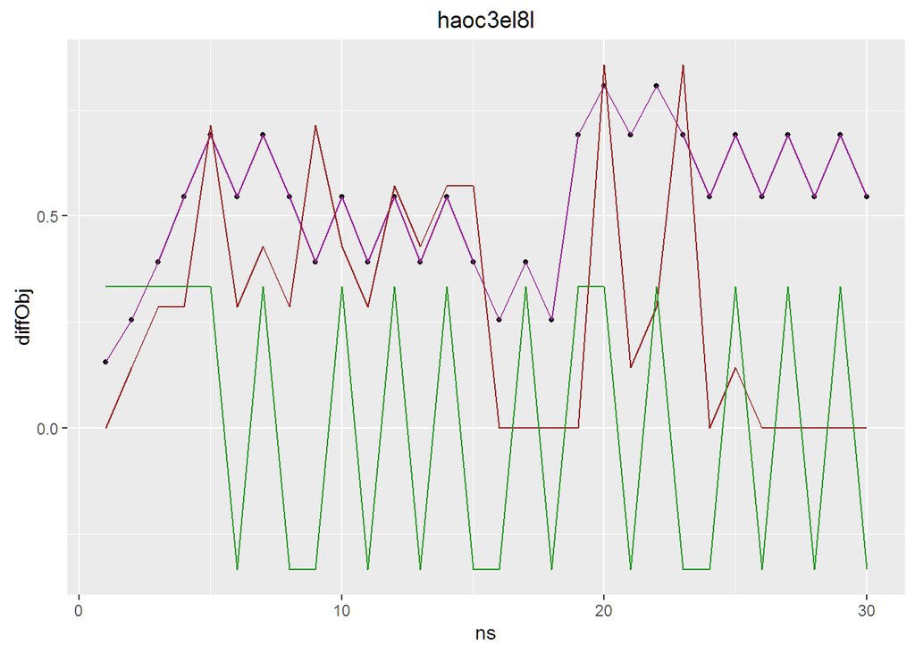

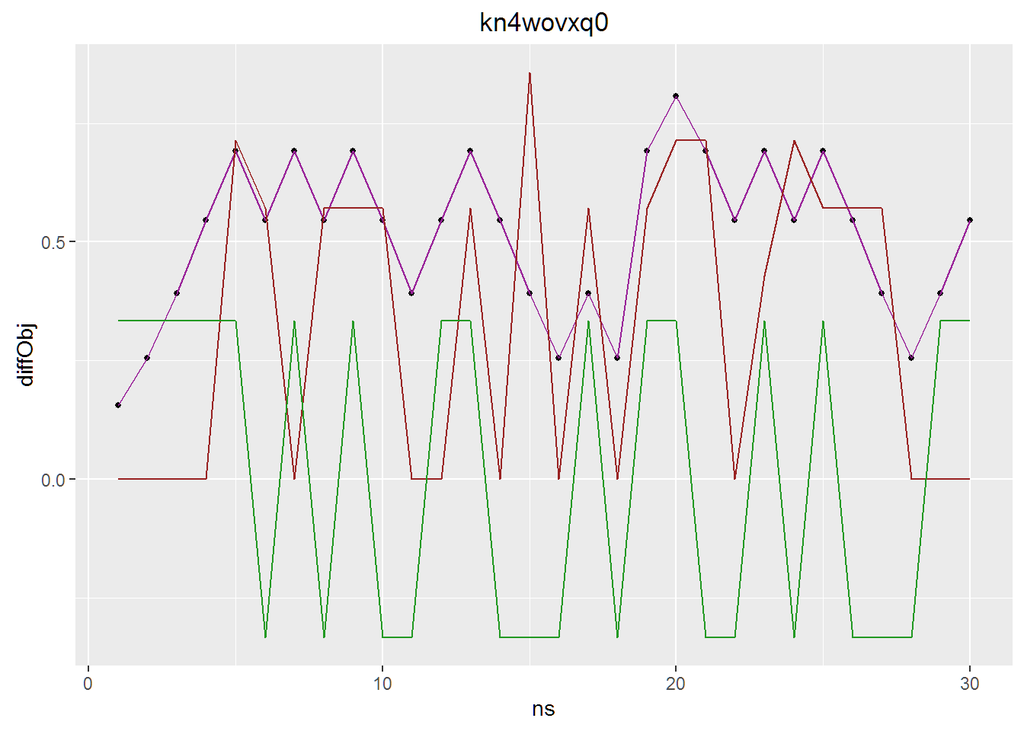

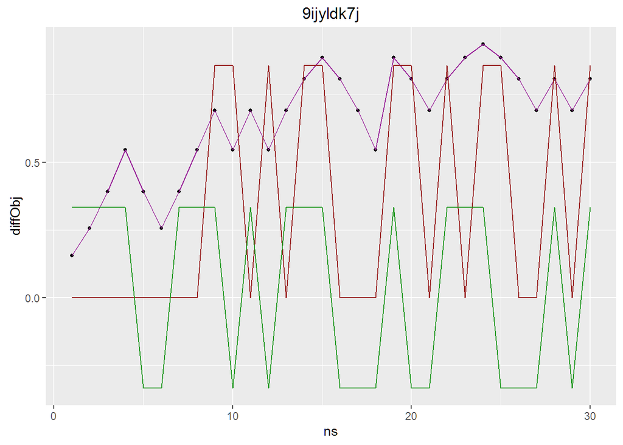

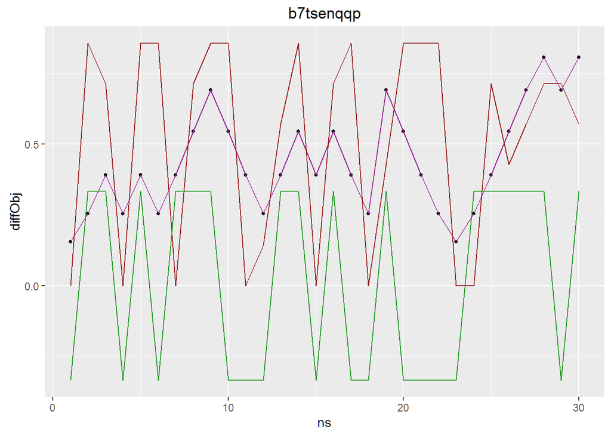

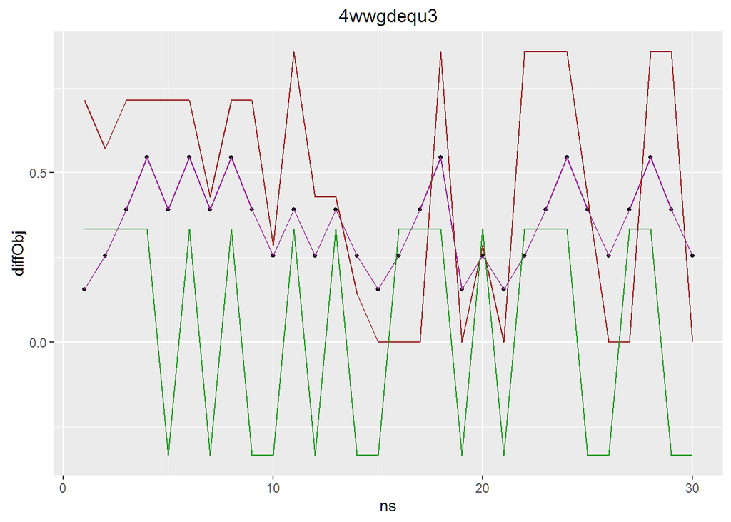

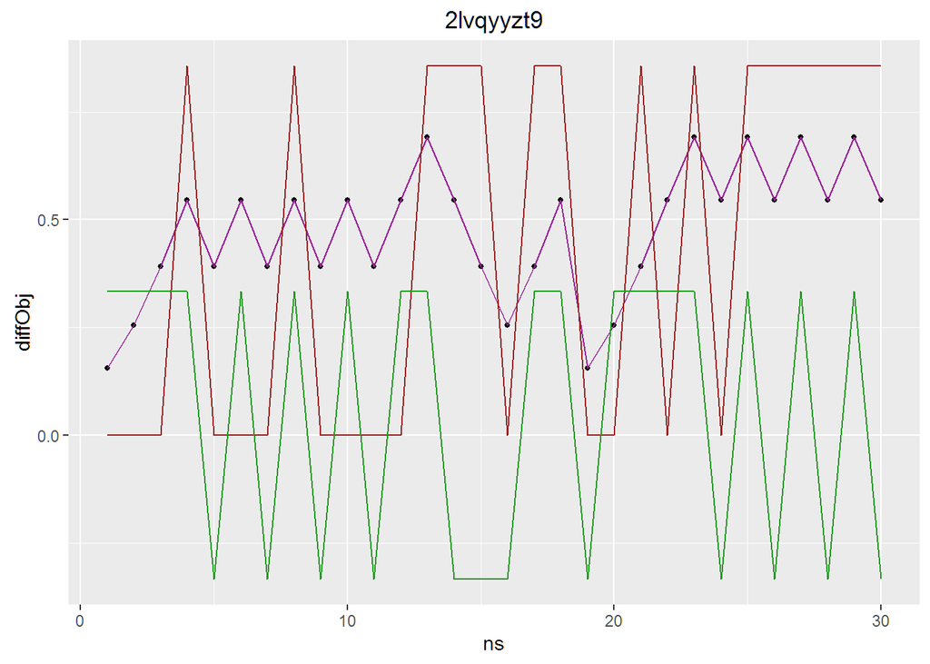

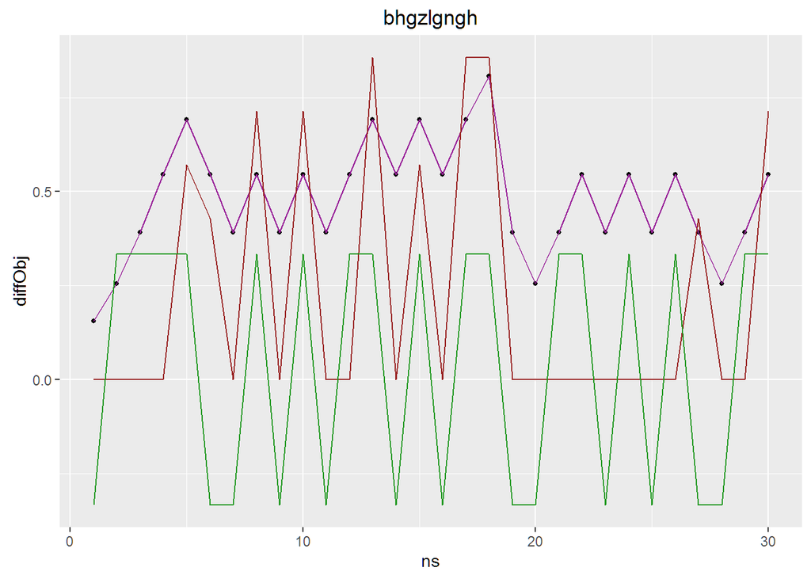

[12 more figures not shown]

# Summary des pvalues

- All lissee 0.81 :(
- Motrice lissee 0.69 :(
- Senso lissee 0.64 :(
- Logique lissee 0.14 :(
- All NBWin 0.054 :(
- Motrice NBWin 0.11 :(
- Senso NBWin 0.94 :(
- Logique NBWin 0.037 *
- All NBFails 0.85 :(
- Motrice NBFails 0.81 :(
- Senso NBFails 0.11 :(
- Logique NBFails 0.12 :(

# Analyses complémentaires

On teste ici une faiblesse éventuelle du modèle. Nous considérons qu’un joueur a une perception faussée de la difficultée si la difficulté objective globale $d_{og}$ est différente de la difficulté subjective $d_{s}$. $d_{og}$ est calculée sur l’ensemble du groupe . $d_{s}$ correspond à la mise du joueur normalisée. Nous étudions le rapport entre nombre d’échecs consécutifs $n_{fail}$ ou nombre de réussites consécutifs $n_{win}$ et l’erreur d’estimation $\epsilon = d_{s} - d_{og}$.

$d_{og}$ a une faiblesse: elle est calculée sur l’ensemble du groupe et donc ne tient pas compte du niveau spécifique de chaque joueur, elle s’éloigne donc de la difficulté réelle $d_{r}$ pour les joueurs qui sortent de la moyenne du groupe, bons ou mauvais. Donc plus un joueur s’éloigne de la moyenne des joueurs, plus l’erreur d’évaluation de la difficulté va être importante: même si $d_{s}$ est parfaite, $\mid d_{s}-d_{og} \mid$ va augmenter car $d_{og}$ devient de plus en plus fausse. Autrement dit, la correlation entre $n_{win}$ et $\epsilon$ provient elle d’une erreur sur la difficulté subjective (exces de confiance) ou sur la difficulté objective. Car justement, plus un joueur est bon (ou mauvais) plus il a de chance d’avoir des suites de succès (ou d’échecs), avant que la difficulté se soit adaptée, ce qui pourrait expliquer une corrélation entre $d_{og}$ et $n_{win}$.